# Bagging

集成学习是指通过构建并结合多个学习分类器来完成学习任务。如果集成是‘同质’的（即所有个体学习器是同一种算法）那么这些个体学习器称为基学习器（base learner）。‘异质’的称为‘组件学习器’（component learner）。

通常认为将多个分类器结合的学习，比单一分类器的学习要准确的多。要想得到好的集成分类器，一个是基分类器要有一定的准确性，至少不能随机扔硬币猜正反还离谱；其次要有多样性，也就是分类器间有差异性存在，这样才能保证泛化能力不至于太差。

# 1 概述

集成学习是近年来机器学习领域中的研究热点之一。经典的两个集成算法是Bagging和AdaBoost，他们分别以某种巧妙的方式将若干基分类器的预测结果进行综合，以达到显著提升分类效果的目的。

## 1.1 个体与集成

集成学习（ensemble learning）通过构建并结合多个学习器来完成学习任务，也称为多分类器系统（multi-classifier system）、基于委员会的学习（committee-based learning）。

集成学习的一般结构：先产生一组个体学习器（individual learner），再用某种策略将它们结合起来。个体学习器通常由一个现有的学习算法从训练数据产生，如决策树算法、BP神经网络等。如果集成中只包含同种类型的个体学习器，则集成是同质的（homogeneous）；同质集成中的个体学习器也称为基学习器（base learner），相应的学习算法称为基学习算法（base learningalgorithm）。如果集成中包含不同类型的个体学习器，则集成是异质的（heterogenous）；异质集成中的个体学习器由不同的学习算法生成，个体学习器称为组件学习器（component learner）。

说了定义，那么集成学习器是否比个体学习器泛化性能更显著呢？先引入弱学习器（weak learner）的定义，弱学习器常指泛化性能略优于随机猜测的学习器，例如在二分类问题上精度略高于50%的分类器。换句话说，弱学习器的结果接近于靠猜。集成学习通过将多个学习器进行结合，通常可以获得比单一学习器显著优越的泛化性能，这对弱学习器尤其明显，因此集成学习的很多理论研究是针对弱学习器进行的，而基学习器有时也被直接成为弱学习器。

现在问题是：集成学习把多个学习器结合起来，怎样能获得比单一学习器更好的性能呢？要获得好的集成，个体学习器应好而不同，即个体学习器要有一定的准确性，即学习器不太坏，并且要有多样性（diversity），即学习器间具有差异。

考虑二分类问题$y\in\{-1,+1\}$和真实函数$f$，假定基分类器的错误率为$\epsilon$，即对每个基分类器$h_i$有
$$P(h_i(x)\neq f(x))=\epsilon$$
假设集成通过简单投票法结合$T$个基分类器，若有超过半数的基分类器正确，则集成分类就正确：
$$H(x)=sign(\sum_{i=1}^{T}h_i(x))$$
假设基分类器的错误率相互独立，则由Hoeffding不等式可知，集成的错误率为
$$P(H(x)\neq f(x))=\sum_{k=0}^{[T/2]}\begin{pmatrix} T \\ k \end{pmatrix}\\(1-\epsilon)^k\epsilon^{T-k}\leq exp(-\frac{1}{2}T(1-2\epsilon)^2$$
上式显示，随着集成中个体分类器数目$T$的增大，集成的错误率将指数级下降，最终趋向于0。
Hoeffding不等式是关于一组随机变量均值的概率不等式。如果$X_1,X_2,···,X_n$为一组独立同分布的参数为$p$的伯努利分布随机变量，$n$为随机变量的个数，定义这组随机变量的均值为：
$$\overline{X}=\frac{X_1+X_2+…+X_n}{n}$$
对于任意$\delta>0$，Hoeffding不等式可以表示为：
$$P(|\overline{X}-E(\overline{X})|\geq \delta)\leq exp(-2\delta^2n^2)$$

如上，集成学习就是把所有个体学习器的结果做简单的投票，这样就能获得比个体学习器更好的泛化性能。等等，没有这么好的事了，要这样说，需要满足一个关键假设：基学习器的误差相互独立。然后在现实任务中，个体学习器时为解决同一问题训练出来的，它们显然不可能相互独立。事实上，个体学习器的准确性和多样性本身就存在冲突。一般的，准确性很高之后，要增加多样性就要牺牲准确性。

因此，如何产生并结合好而不同的个体学习器，就是集成学习研究的核心，就是怎么集成？集成怎么样的个体学习器？根据个体学习器的生成方式，目前的集成学习方法大致可分为两大类：  
1）个体学习器间存在强依赖关系、必须串行生成的序列化方法，代表是Boosting；  
2）个体学习器间不存在强依赖关系、可同时生成的并行化方法，代表是Bagging和随机森林（Random Forest）。

## 1.2 Boosting

先从训练集中训练出一个基分类器，利用此分类器进行分类，根据分类结果对训练样本的分布进行调整，对于先前分错的训练样本在后续的分类中享有更多关注，然后对于调整后的训练样本，再训练第二个基分类器；就这样迭代重复进行，直至满足某个截止条件。Adaboost是Boosting的典型代表。

算法优点：应用于分类问题。Adaboost分类器可以排除一些不必要的训练数据特征，并将关键放在关键的训练数据上面。

**过程分析**

Adaboost，一开始就提到是一种迭代算法，也是一个简单的弱分类算法提升过程，怎样个提升法呢？由于单单依靠弱分类算法还难以保证分类结果的准确性，因而Adaboost的提升过程就是通过不断的训练，提高对数据的分类能力。详细流程如下：

1. 先通过对N个训练样本（预先给定）的学习（Offline Learning)得到第一个弱分类器；

2. 将分错的样本（怎么知道样本被分错了呢？）和其它的新数据一起（错了就要和待审核的一起），构成一个新的N个的训练样本，重复第一步，即通过对这个样本的学习得到第二个弱分类器（体现迭代）；

3. 将1和2都分错了的样本（其实就是2里分错的样本，因为1里错的样本已经全部给到2了），加上其它的新样本构成另一个新的N个的训练样本，通过对这个样本的学习得到第三个弱分类器；

4. 最终，经过提升的强分类器，即某个数据被分为哪一类要通过多数表决

**存在的问题及改进方法**

对于boosting算法，存在两个问题：

1. 如何调整训练集，使得在训练集上训练的弱分类器得以进行；换句话说，就是，当每次上层N个训练样本训练结束之后，如何调整训练集，将分错的样本与新数据结合起来，构成新的N个训练样本，供下一层学习。

2. 如何将训练得到的各个弱分类器联合起来形成强分类器；换句话说，要纪录每次得到的弱分类器，最后将每个样本在每个分类器中得到的数据，进行比较，投票。多数表决通过！

针对以上两个问题，Adaboost算法进行了调整：（引入了权重的概念）

1. 使用加权后选取的训练数据代替随机选取的训练样本，这样，将训练的焦点集中在比较难分的训练数据样本上；

2. 将弱分类器联合起来，使用加权的投票机制代替平均投票机制。让分类效果好的弱分类器具有较大的权重，而分类效果差的分类器具有较小的权重。

**关于权重的理解**

Adaboost算法中不同的训练集是通过调整每个样本对应的权重来实现的。开始时，每个样本对应的权重是相同的，即其中n为样本个数，在此样本分布下训练出一弱分类器。对于分类错误的样本，加大其对应的权重；而对于分类正确的样本，降低其权重，这样，分错的样本就被突显出来（权重大的），从而得到一个新的样本分布。

在新的样本分布下，再次对样本进行训练，又得到一个弱分类器，又加大分类错误的样本的权重。

依次类推，经过T次循环，得到T个弱分类器，把这T个弱分类器按一定的权重叠加（boost）起来，得到最终想要的强分类器！

**Adaboost算法的具体步骤**

1. 给定训练样本集S，其中X和Y分别对应于正例样本和负例样本（即两个分类结果）；T为训练的最大循环次数；

2. 初始化样本权重为1/n，即为训练样本的初始概率分布（即离散型均匀分布）；

3. 第一次迭代：

（1）训练样本的概率分布相当下，训练弱分类器；

（2）计算弱分类器的错误率（怎么计算呢？错误率 ＝ 分类出错的样本个数 / 总的样本个数）；

（3）选取合适阀值，使得误差最小；

（4）更新样本权重（新的样本权重替代旧的）；

经过T次循环后，得到T个弱分类器，按更新的权重叠加，最终得到强分类器。

步骤总结：上述的算法步骤迭代了T次的主循环，每一次循环根据当前的权重分布对样本x定一个分布P，然后对这个分布下的所有样本使用弱学习算法得到一个弱分类器。每一次迭代，都要对权重进行更新！更新的规则就是：减小弱分类器分类效果较好的数据的概率，增大弱分类器分类效果较差的数据的概率，最终的分类器是一个所有弱分类器的加权平均

## 1.3 Bagging与随机森林

Bagging 是并行集成学习的代表。基于有放回的采样，采样出T个含m个样本的采样集，有放回的采样使得样本在采样集中有的多次出现，有的从未出现，这样既保证了训练数据的不同，使得基分类器有差异，但又不能差太多，否则若每个子集完全不同，则每个分类器只用到了一小部分训练数据，不足以进行有效学习。

Bagging的优势:高效而且可以不经修改地适用于多分类任务、回归任务；此外由于它只用了一部分样本，剩下的部分可用来测试，便于交叉验证，提升泛化性能。

随机森林在构建Bagging集成的基础上，在决策树训练时引入了随机属性选择。即，传统决策树在划分属性时在当前节点的属性中选择一个最优的属性，而在随机森林中，每个决策树的每个节点，会先随机选择一个包含k个属性的子集，然后再从这k个属性中选择一个最优属性用于划分;

随机森林的优势：训练效率高于bagging，因为Bagging用的是“确定性”的决策树，要对所有节点的属性进行考察，而随机森林用的是随机性决策树，只需要考察一个属性子集，一个是整体，一个是部分，随机森林效率高一些。

随机森林改进点:

森林中任意两棵树的相关性：相关性越大，错误率越大；  
森林中每棵树的分类能力：每棵树的分类能力越强，整个森林的错误率越低。

## 1.4 Bagging与Boosting算法的对比

Boosting与Bagging 相比来说最大的区别就是： Boosting是串行的，而Bagging中所有的分类器是可以同时生成的，之间没有什么关系，而Boosting中则必须先生成第一个分类器，然后根据第一个分类器的结果生成第二个分类器，依次往后进行。

| 项目 | Bagging | Boosting |
| --- | --- | --- |
| 结构 | 并行 | 串行 |
| 训练集 | 独立 | 依赖 |
| 测试 | 可并行 | 需串行 |
| 作用 | 减小方差 | 减小偏差 |

## 1.5 方差与偏差

机器学习模型的Bias和Variance分析，Understanding the Bias-Variance Tradeoff（ http://scott.fortmann-roe.com/docs/BiasVariance.html ）中的一副图生动形象地为我们展示了偏差和方差的关系：

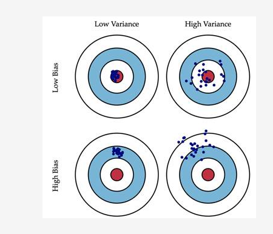

简单来说，一个模型越复杂，对训练样本的拟合度会越高，其Bias会越小（训练误差小）。但是，由于对数据过于敏感，生成的模型的变化范围可能比较大（Variance较大），可能导致在测试数据上性能的不确定性较高。

# 2 R的实现

## 2.1 相关软件包

本章节将使用adabag软件包来实现算法，这个软件包主要专注于Bagging和Boosting两个算法，含有若干相关函数。

## 2.2 核心函数

### 2.2.1 bagging()函数

函数bagging()的基本格式是：

```
bagging(formula, data, mfinal = 100, control, par=FALSE,...)
```

其中，bagging()函数含有4个参数。  
formula参数用于建模的公式，格式为 y~x1+x2+x3；  
data中放置待训练的数据集；  
mfinal参数表示算法的迭代次数，也就是基分类器的个数，可以设置为任意整数，缺失值为100；  
control参数与rpart()函数中的相同，用于控制基分类器的参数。

### 2.2.2 boosting()函数

函数boosting()中的Adaboost算法以分类树为基分类器，基本格式为：

```
boosting(formula, data, boos = TRUE, mfinal = 100, coeflearn = 'Breiman', control,...)
```

其中，formula、data、mfinal及control参数与bagging()函数中的完全相同；  
boos参数用于选择迭代过程中，是否用各观测样本的相应权重来抽取boostrap样本，其默认值为TRUE，如果取FALSE，则每一个观测样本都以其相应权重在迭代过程中被使用；  
coeflearn用于选择权重更新系数alpha的计算方式，默认取Breiman，即alpha = 1/2ln((1-err)/err)，另外也可以更改设置为“Freund”或“Zhu”。

## 2.3 数据集

本章我们使用用于多元回归树的mvpart软件包中的car.test.frame数据集进行演示，我们首先对其进行简单的了解。首先需要进行mvpart软件包的安装，这里的安装稍微较为复杂，需先安装devtools软件包来实现，具体操作如下：

```r
## install.packages("devtools")              # 安装devtools软件包
## devtools::install_github("cran/mvpart")   # 安装mvpart镜像
## devtools::install_github("cran/MVPARTwrap") # 安装MVPARTwrap镜像
## install.packages("mvpart")                # 安装mvpart软件包
library(mvpart)                              # 加载mvpart软件包
data("car.test.frame")                       # 获取car.test.frame数据集
head(car.test.frame)                         # 显示car.test.frame数据集的前6行
```

```
##                  Price   Country Reliability Mileage  Type Weight Disp.
## Eagle Summit 4    8895       USA           4      33 Small   2560    97
## Ford Escort   4   7402       USA           2      33 Small   2345   114
## Ford Festiva 4    6319     Korea           4      37 Small   1845    81
## Honda Civic 4     6635 Japan/USA           5      32 Small   2260    91
## Mazda Protege 4   6599     Japan           5      32 Small   2440   113
## Mercury Tracer 4  8672    Mexico           4      26 Small   2285    97
##                   HP
## Eagle Summit 4   113
## Ford Escort   4   90
## Ford Festiva 4    63
## Honda Civic 4     92
## Mazda Protege 4  103
## Mercury Tracer 4  82
```

```r
summary(car.test.frame)                      # 获取car.test.frame数据集的概况信息
```

```
##      Price            Country    Reliability       Mileage
##  Min.   : 5866   USA      :26   Min.   :1.000   Min.   :18.00
##  1st Qu.: 9932   Japan    :19   1st Qu.:2.000   1st Qu.:21.00
##  Median :12216   Japan/USA: 7   Median :3.000   Median :23.00
##  Mean   :12616   Korea    : 3   Mean   :3.388   Mean   :24.58
##  3rd Qu.:14933   Germany  : 2   3rd Qu.:5.000   3rd Qu.:27.00
##  Max.   :24760   France   : 1   Max.   :5.000   Max.   :37.00
##                  (Other)  : 2   NA's   :11
##       Type        Weight         Disp.             HP
##  Compact:15   Min.   :1845   Min.   : 73.0   Min.   : 63.0
##  Large  : 3   1st Qu.:2571   1st Qu.:113.8   1st Qu.:101.5
##  Medium :13   Median :2885   Median :144.5   Median :111.5
##  Small  :13   Mean   :2901   Mean   :152.1   Mean   :122.3
##  Sporty : 9   3rd Qu.:3231   3rd Qu.:180.0   3rd Qu.:142.8
##  Van    : 7   Max.   :3855   Max.   :305.0   Max.   :225.0
##
```

在获取完以上信息之后，我们来看car.test.frame数据集的基本信息。它一共包含60个样本以及8个变量，分别为“价格Price”、“产地Country”、“可靠性Reliability”、“英里数Mileage”、“类型Type”、“车重Weight”、“发动机功率Disp.”和“净马力HP”。

为了之后分析的过程便于理解，我们将数据集变量名改为中文，“英里数Mileage”换算为“油耗”指标，实现代码如下：

```r
car.test.frame$Mileage <- 100*4.546/(1.6*car.test.frame$Mileage)  # 将“英里数Mileage”换算为“油耗”指标
names(car.test.frame) <- c("价格","产地","可靠性","油耗","类型","车重","发动机功率","净马力")  # 将变量名个呢更换为中文
head(car.test.frame)
```

```
##                  价格      产地 可靠性      油耗  类型 车重 发动机功率
## Eagle Summit 4   8895       USA      4  8.609848 Small 2560         97
## Ford Escort   4  7402       USA      2  8.609848 Small 2345        114
## Ford Festiva 4   6319     Korea      4  7.679054 Small 1845         81
## Honda Civic 4    6635 Japan/USA      5  8.878906 Small 2260         91
## Mazda Protege 4  6599     Japan      5  8.878906 Small 2440        113
## Mercury Tracer 4 8672    Mexico      4 10.927885 Small 2285         97
##                  净马力
## Eagle Summit 4      113
## Ford Escort   4      90
## Ford Festiva 4       63
## Honda Civic 4        92
## Mazda Protege 4     103
## Mercury Tracer 4     82
```

为了进一步了解各个变量的信息，我们分别使用str()函数和summary()函数。

```r
str(car.test.frame)    # 探寻数据集内部的结构
```

```
## 'data.frame':    60 obs. of  8 variables:
##  $ 价格      : int  8895 7402 6319 6635 6599 8672 7399 7254 9599 5866 ...
##  $ 产地      : Factor w/ 8 levels "France","Germany",..: 8 8 5 4 3 6 4 5 3 3 ...
##  $ 可靠性    : int  4 2 4 5 5 4 5 1 5 NA ...
##  $ 油耗      : num  8.61 8.61 7.68 8.88 8.88 ...
##  $ 类型      : Factor w/ 6 levels "Compact","Large",..: 4 4 4 4 4 4 4 4 4 4 ...
##  $ 车重      : int  2560 2345 1845 2260 2440 2285 2275 2350 2295 1900 ...
##  $ 发动机功率: int  97 114 81 91 113 97 97 98 109 73 ...
##  $ 净马力    : int  113 90 63 92 103 82 90 74 90 73 ...
```

在如下的summary()输出结果中，对于因子型变量，给出了各个水平分别对应的样本个数，而数值型数据则给出了最值及中位数等基本统计量指标。

```r
summary(car.test.frame)    # 获取car.test.frame数据集的信息
```

```
##       价格              产地        可靠性           油耗
##  Min.   : 5866   USA      :26   Min.   :1.000   Min.   : 7.679
##  1st Qu.: 9932   Japan    :19   1st Qu.:2.000   1st Qu.:10.523
##  Median :12216   Japan/USA: 7   Median :3.000   Median :12.353
##  Mean   :12616   Korea    : 3   Mean   :3.388   Mean   :11.962
##  3rd Qu.:14933   Germany  : 2   3rd Qu.:5.000   3rd Qu.:13.530
##  Max.   :24760   France   : 1   Max.   :5.000   Max.   :15.785
##                  (Other)  : 2   NA's   :11
##       类型         车重        发动机功率        净马力
##  Compact:15   Min.   :1845   Min.   : 73.0   Min.   : 63.0
##  Large  : 3   1st Qu.:2571   1st Qu.:113.8   1st Qu.:101.5
##  Medium :13   Median :2885   Median :144.5   Median :111.5
##  Small  :13   Mean   :2901   Mean   :152.1   Mean   :122.3
##  Sporty : 9   3rd Qu.:3231   3rd Qu.:180.0   3rd Qu.:142.8
##  Van    : 7   Max.   :3855   Max.   :305.0   Max.   :225.0
##
```

由于在建模过程中，主要以“油耗”变量作为目标变量，所以考虑添加一个变量“分组油耗”，也就是说将“油耗”变量划分为三个组别，A组：11.6-15.8、B组：9-11.6、C组：7.7-9个油，成为含有3个水平的因子变量。

```r
Group_Mileage <- matrix(0,60,1)  # 构造Group_Mileage矩阵来存放新变量
Group_Mileage[which(car.test.frame$油耗>=11.6)] <- "A"  # 将油耗在11.6-15.8的样本Group_Mileage取值为A
Group_Mileage[which(car.test.frame$油耗<=9)] <- "C" # 将油耗在7.7-9的样本Group_Mileage取值为C
Group_Mileage[which(Group_Mileage==0)] <- "B"  # 将油耗不在组A和组C的样本取值为B
car.test.frame$"分组油耗" <- Group_Mileage     # 添加新变量“分组变量”，取值为Group_Mileage
car.test.frame[1:10, c(4,9)]                   # 查看前10行数据的“油耗”及“分组油耗”信息
```

```
##                       油耗 分组油耗
## Eagle Summit 4    8.609848        C
## Ford Escort   4   8.609848        C
## Ford Festiva 4    7.679054        C
## Honda Civic 4     8.878906        C
## Mazda Protege 4   8.878906        C
## Mercury Tracer 4 10.927885        B
## Nissan Sentra 4   8.609848        C
## Pontiac LeMans 4 10.147321        B
## Subaru Loyale 4  11.365000        B
## Subaru Justy 3    8.356618        C
```

我们使用数据集的四分之一样本作为测试集来评价分类器的性能，也就是说3/4的样本建立训练集，1/4的样本建立测试集。为了保持数据集分布，使用sampling软件包中的strata()函数来进行分层抽样，即在A、B、C组的英里数样本中分别抽取1/4共同构成测试集。以下为训练集与测试集的构造过程：

```r
a <- round(1/4*sum(car.test.frame$分组油耗 == "A")) # 将A组的测试集样本数记为a
b <- round(1/4*sum(car.test.frame$分组油耗 == "B")) # 将B组的测试集样本数记为b
c <- round(1/4*sum(car.test.frame$分组油耗 == "C")) # 将C组的测试集样本数记为c

a;b;c  # 分别输出a、b、c的值
```

```
## [1] 9
```

```
## [1] 4
```

```
## [1] 2
```

```r
library(sampling)   # 载入sampling软件包
sub <- strata(car.test.frame, stratanames = "分组油耗",
              size = c(c,b,a), method = "srswor")   # 将“分组油耗”变量进行分层抽样
sub    # 显示抽样样本的信息
```

```
##    分组油耗 ID_unit      Prob Stratum
## 1         C       1 0.2222222       1
## 18        C      18 0.2222222       1
## 8         B       8 0.2500000       2
## 13        B      13 0.2500000       2
## 22        B      22 0.2500000       2
## 26        B      26 0.2500000       2
## 14        A      14 0.2571429       3
## 27        A      27 0.2571429       3
## 35        A      35 0.2571429       3
## 38        A      38 0.2571429       3
## 42        A      42 0.2571429       3
## 47        A      47 0.2571429       3
## 49        A      49 0.2571429       3
## 57        A      57 0.2571429       3
## 58        A      58 0.2571429       3
```

```r
car_train <- car.test.frame[-sub$ID_unit, ] # 生成训练集car_train
car_test <- car.test.frame[sub$ID_unit, ]   # 生成测试集car_test
nrow(car_train); nrow(car_test)             # 显示训练集、测试集的行数，判断其比例是否为3:1
```

```
## [1] 45
```

```
## [1] 15
```

# 3 应用案例

下面我们将分别使用bagging()与boosting()函数来实现相应的算法。

## 3.1 Bagging算法

首先，我们需要下载和载入所需的软件包

```r
## install.packages('adabag')    # 下载adabag软件包
## install.packages('rpart')     # 下载rpart软件包
library(adabag)               # 载入adabag软件包
library(rpart)                # 载入rpart软件包
```

### 3.1.1 对训练集data_train运行Bagging算法

下面我们开始使用bagging()函数建立模型，为了便于说明输出结果，仅在迭代过程中生5棵决策树，即设定mfinal = 5.

```r
car_train$油耗 <- as.factor(car_train$油耗)      # 将car_train中因变量转换成因子型
formula_Car <- 油耗~价格+产地+可靠性+类型+车重+发动机功率+净马力  # 设定模型公式
bag <- bagging(formula_Car, car_train, control=(minsplit=0), mfinal = 5)   # 使用bagging()函数建模，记为bag
names(bag)  # 查看模型bag中生成的所有输出项名称
```

```
## [1] "formula"    "trees"      "votes"      "prob"       "class"
## [6] "samples"    "importance" "terms"      "call"
```

```r
bag$formula  # 将建立bag模型的公式显示出来
```

```
## 油耗 ~ 价格 + 产地 + 可靠性 + 类型 + 车重 + 发动机功率 + 净马力
```

第二项为迭代过程中所生成的每棵决策树trees的具体情况，而这里树的个数即为参数mfinal的取值，如下仅输出了其中第二棵决策树的具体构成。

```r
bag$trees[2]  # 模型bag中第二棵决策树的构成
```

```
## [[1]]
## n= 45
##
## node), split, n, loss, yval, (yprob)
##       * denotes terminal node
##
## 1) root 45 37 12.3532608695652 (0 0 0 0.044 0.022 0.022 0.022 0.11 0.089 0.022 0.089 0.18 0.067 0.089 0.067 0.044 0.13)
##   2) 类型=Compact,Medium,Small,Sporty 33 26 12.3532608695652 (0 0 0 0.061 0.03 0.03 0.03 0.15 0.12 0.03 0.12 0.21 0.091 0.12 0 0 0)
##     4) 发动机功率< 138 18 13 10.5231481481481 (0 0 0 0.11 0.056 0.056 0.056 0.28 0.22 0.056 0.17 0 0 0 0 0 0) *
##     5) 发动机功率>=138 15  8 12.3532608695652 (0 0 0 0 0 0 0 0 0 0 0.067 0.47 0.2 0.27 0 0 0) *
##   3) 类型=Large,Van 12  6 15.7847222222222 (0 0 0 0 0 0 0 0 0 0 0 0.083 0 0 0.25 0.17 0.5) *
```

```r
bag$votes[30:35,]         # 模型bag中第30至第35个样本的投票情况
```

```
##      [,1] [,2] [,3] [,4] [,5] [,6] [,7] [,8] [,9] [,10] [,11] [,12] [,13]
## [1,]    0    0    0    0    0    0    0    0    0     0     0     3     1
## [2,]    0    0    0    0    0    0    0    0    0     0     0     3     1
## [3,]    0    0    0    0    0    0    0    0    0     0     0     3     1
## [4,]    0    0    0    0    0    0    0    0    0     0     0     3     1
## [5,]    0    0    0    0    0    0    0    0    0     0     0     3     1
## [6,]    0    0    0    0    0    0    0    0    0     0     0     3     1
##      [,14] [,15] [,16] [,17]
## [1,]     0     1     0     0
## [2,]     0     1     0     0
## [3,]     0     1     0     0
## [4,]     0     1     0     0
## [5,]     0     1     0     0
## [6,]     0     1     0     0
```

第四项为每一个样本属于各类的概率prob矩阵，可以简单看作是votes结果的百分比形式。

```r
bag$prob[30:35,]   # 模型bag中第30至第35个样本被预测为各类别的概率
```

```
##      [,1] [,2] [,3] [,4] [,5] [,6] [,7] [,8] [,9] [,10] [,11] [,12] [,13]
## [1,]    0    0    0    0    0    0    0    0    0     0     0   0.6   0.2
## [2,]    0    0    0    0    0    0    0    0    0     0     0   0.6   0.2
## [3,]    0    0    0    0    0    0    0    0    0     0     0   0.6   0.2
## [4,]    0    0    0    0    0    0    0    0    0     0     0   0.6   0.2
## [5,]    0    0    0    0    0    0    0    0    0     0     0   0.6   0.2
## [6,]    0    0    0    0    0    0    0    0    0     0     0   0.6   0.2
##      [,14] [,15] [,16] [,17]
## [1,]     0   0.2     0     0
## [2,]     0   0.2     0     0
## [3,]     0   0.2     0     0
## [4,]     0   0.2     0     0
## [5,]     0   0.2     0     0
## [6,]     0   0.2     0     0
```

第五项为Bagging算法对于各个样本所属类别class的最终判断。这个结果与上述两个votes和prob结果相符

```r
bag$class[30:35]   # 模型bag对于第30至第35个样本的预测类别
```

```
## [1] "12.3532608695652" "12.3532608695652" "12.3532608695652"
## [4] "12.3532608695652" "12.3532608695652" "12.3532608695652"
```

第六项为5次迭代过程中所使用的boostrap样本。

```r
bag$samples[30:35,]   # 模型bag中第30至第35个样本在5次迭代过程中的抽样情况
```

```
##      [,1] [,2] [,3] [,4] [,5]
## [1,]    1   42   39   45    6
## [2,]   15   34    4   44   31
## [3,]    2   27   38   36    7
## [4,]    3   14   43   29   37
## [5,]   21   25   11   45   13
## [6,]    4   24   41    5   12
```

第七项为各输入变量在分类过程中的相对重要性，并绘制其中变量重要程度的条形图。从图中可以看出，数值越高的变量重要性越高。

```r
bag$importance    # 模型bag中各输入变量的相对重要性
```

```
##       产地       车重 发动机功率       价格     净马力     可靠性
##  13.029326   7.275970  16.510254   0.000000   6.823976   0.000000
##       类型
##  56.360473
```

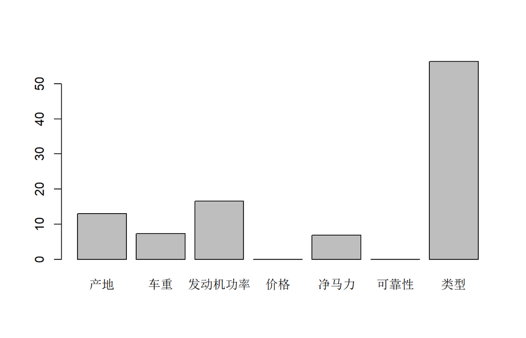

```r
barplot(bag$importance)   # 绘制重要性条形图
```

```r
bag1 <- bagging(formula_Car, car_train, mfinal = 5, control = rpart.control(maxdepth = 3))   # 通过control参数控制基分类树的复杂度
bag1$terms[2]   # 查看第二棵子树的结构
```

```
## 油耗 ~ 产地
## attr(,"variables")
## list(油耗, 产地)
## attr(,"factors")
##      产地
## 油耗    0
## 产地    1
## attr(,"term.labels")
## [1] "产地"
## attr(,"order")
## [1] 1
## attr(,"intercept")
## [1] 1
## attr(,"response")
## [1] 1
## attr(,".Environment")
## <environment: R_GlobalEnv>
## attr(,"predvars")
## list(油耗, 产地)
## attr(,"dataClasses")
##     油耗     产地
## "factor" "factor"
```

### 3.1.2 对测试集的目标变量进行预测

下面我们使用如上建立的bag模型来对测试集中的油耗进行预测，迭代次数仍然设置为5。

```r
car_test$油耗 <- as.factor(car_test$油耗)  # 将测试集数据的油耗变量变为因子型
pre_bag <- predict(bag, car_test)   # 使用bag模型对测试集中目标变量进行预测
names(pre_bag)  # 查看预测结果的项目名称
```

```
## [1] "formula"   "votes"     "prob"      "class"     "confusion" "error"
```

第一项formula为建模公式，第二项votes为5棵子树对这15个测试样本的投票情况。

```r
pre_bag$votes[1:10,]    # 预测结果pre_bag中前10个样本的投票情况
```

```
##       [,1] [,2] [,3] [,4] [,5] [,6] [,7] [,8] [,9] [,10] [,11] [,12] [,13]
##  [1,]    0    1    0    1    0    0    0    2    0     0     0     0     0
##  [2,]    0    1    0    0    0    0    0    3    0     1     0     0     0
##  [3,]    0    1    0    2    0    0    0    2    0     0     0     0     0
##  [4,]    0    1    0    1    0    0    0    2    0     0     0     0     0
##  [5,]    0    1    0    0    0    0    0    3    0     1     0     0     0
##  [6,]    0    0    0    0    0    0    0    1    0     0     0     3     1
##  [7,]    0    1    0    0    0    0    0    1    0     0     0     1     0
##  [8,]    0    0    0    0    0    0    0    1    0     0     0     3     1
##  [9,]    0    0    0    1    0    0    0    2    0     0     0     2     0
## [10,]    0    0    0    0    0    0    0    0    0     0     0     3     1
##       [,14] [,15] [,16] [,17]
##  [1,]     0     1     0     0
##  [2,]     0     0     0     0
##  [3,]     0     0     0     0
##  [4,]     0     1     0     0
##  [5,]     0     0     0     0
##  [6,]     0     0     0     0
##  [7,]     0     1     1     0
##  [8,]     0     0     0     0
##  [9,]     0     0     0     0
## [10,]     0     1     0     0
```

另外，不平衡数据问题在理论和实际中都是一个日趋重要的话题，如有兴趣可以查阅相关资料进行更加深入的了解。

## 3.2 Adaboost算法

boosting()函数与bagging()函数的使用方式相同，不再赘述。我们直接对训练集car_train进行adaboost算法，并对测试集car_test进行预测，迭代次数依旧为5。

```r
boo <- boosting(formula_Car, car_train, mfinal = 5)  # 构建Adaboost模型
boo$votes[30:35,]      # 模型boo中第30个至第35个样本的投票情况
```

```
##      [,1] [,2] [,3] [,4] [,5] [,6] [,7] [,8] [,9] [,10] [,11]       [,12]
## [1,]    0    0    0    0    0    0    0    0    0     0     0 0.010000013
## [2,]    0    0    0    0    0    0    0    0    0     0     0 0.010000013
## [3,]    0    0    0    0    0    0    0    0    0     0     0 0.010000013
## [4,]    0    0    0    0    0    0    0    0    0     0     0 0.010000013
## [5,]    0    0    0    0    0    0    0    0    0     0     0 0.010000013
## [6,]    0    0    0    0    0    0    0    0    0     0     0 0.008000011
##      [,13]       [,14] [,15] [,16] [,17]
## [1,]     0 0.000000000     0     0     0
## [2,]     0 0.000000000     0     0     0
## [3,]     0 0.000000000     0     0     0
## [4,]     0 0.000000000     0     0     0
## [5,]     0 0.000000000     0     0     0
## [6,]     0 0.002000003     0     0     0
```

```r
pre_boo <- predict(boo, car_test)     # 使用boo模型对测试集中的目标变量的取值进行预测
pre_boo$votes[1:10,]   # 预测结果boo的前10个样本的投票情况
```

```
##       [,1]        [,2] [,3]        [,4] [,5] [,6] [,7]        [,8] [,9]
##  [1,]    0 0.002000003    0 0.004000005    0    0    0 0.004000005    0
##  [2,]    0 0.000000000    0 0.004000005    0    0    0 0.006000008    0
##  [3,]    0 0.002000003    0 0.004000005    0    0    0 0.004000005    0
##  [4,]    0 0.002000003    0 0.004000005    0    0    0 0.004000005    0
##  [5,]    0 0.000000000    0 0.004000005    0    0    0 0.006000008    0
##  [6,]    0 0.000000000    0 0.000000000    0    0    0 0.002000003    0
##  [7,]    0 0.000000000    0 0.000000000    0    0    0 0.002000003    0
##  [8,]    0 0.000000000    0 0.000000000    0    0    0 0.002000003    0
##  [9,]    0 0.000000000    0 0.002000003    0    0    0 0.008000011    0
## [10,]    0 0.000000000    0 0.000000000    0    0    0 0.000000000    0
##       [,10] [,11]       [,12] [,13]       [,14] [,15]       [,16] [,17]
##  [1,]     0     0 0.000000000     0 0.000000000     0 0.000000000     0
##  [2,]     0     0 0.000000000     0 0.000000000     0 0.000000000     0
##  [3,]     0     0 0.000000000     0 0.000000000     0 0.000000000     0
##  [4,]     0     0 0.000000000     0 0.000000000     0 0.000000000     0
##  [5,]     0     0 0.000000000     0 0.000000000     0 0.000000000     0
##  [6,]     0     0 0.008000011     0 0.000000000     0 0.000000000     0
##  [7,]     0     0 0.006000008     0 0.000000000     0 0.002000003     0
##  [8,]     0     0 0.008000011     0 0.000000000     0 0.000000000     0
##  [9,]     0     0 0.000000000     0 0.000000000     0 0.000000000     0
## [10,]     0     0 0.008000011     0 0.002000003     0 0.000000000     0
```

# 4 本章汇总

| 项目 | 类别 | 作用 |
| --- | --- | --- |
| adaba | 软件包 | 提供bagging()函数和boosting()函数 |
| bagging() | 函数 | 实现Bagging算法 |
| boosting() | 函数 | 实现Boosting算法 |
| car.test.frame | 数据集 | mvpart软件包提供的汽车数据集 |

# 5 参考文献

[1] 周志华. 机器学习 : = Machine learning[M]. 清华大学出版社, 2016.  
[2] 黄文, 王正林. 数据挖掘 : R语言实战[M]. 电子工业出版社, 2014.